# Linear Regression, What You Thought You Knew

Jeremiah Lowhorn, Thomas Egan

9/6/2018

# Regression

Regression is a fundamental statistical method that forms the basis for many other highly advanced machine learning techniques. An intimate understanding of the underlying mathematics of regression is essential to understanding higher level procedures.

# Motivating Example

- Imagine we have three data points: (latency, throughput) (40,3),(60,2),(80,1)
- The goal is to find a linear equation that fits these points
- Remember high school algebra slope intercept form
  - $Y = mx + b$
  - $y = throughput, x = latency, b = constant (intercept), m = slope$
- Which can be written: $throughput = \beta latency + C$
- Here $\beta$ and the Constant are unknown parameters which can be solved in a system of linear equations:
- $\beta 40 + C = 3 \\ \beta 60 + C = 2 \\ \beta 80 + C = 1$

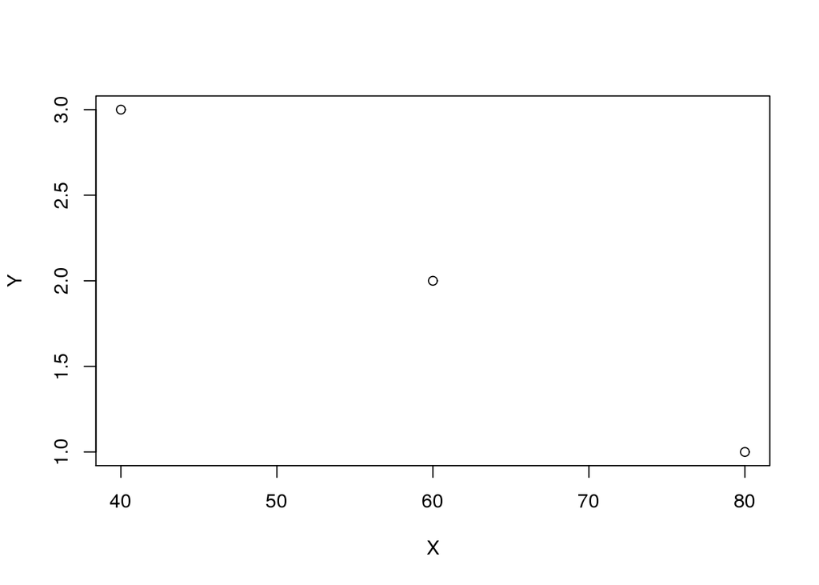

```r
X <- c(40,60,80)
Y <- c(3,2,1)
##lets see this visually
plot(X,Y)
```

### How do we solve for $\beta$ and C?

Take the inverse of the first equation for elimination of the constant and we get:

$\frac{-40\beta-C=-3\\+ 60\beta+C=2}{20\beta=-1}$

Solve for $\beta$ and we get:

$\beta = -\frac{1}{20}$

We can now use $\beta$ to solve for the constant in the third equation:

$-\frac{80}{20} + C = 1$

Now C becomes:

$C = 1 + \frac{80}{20} = 5$

Had our second equation had a latency measure of 70 we would have to solve this twice from top down and then bottom up and our coefficients would be estimates. This is where the idea of least squares comes in to play. More on that later…

### Visualization and R Confirmation of our Solution

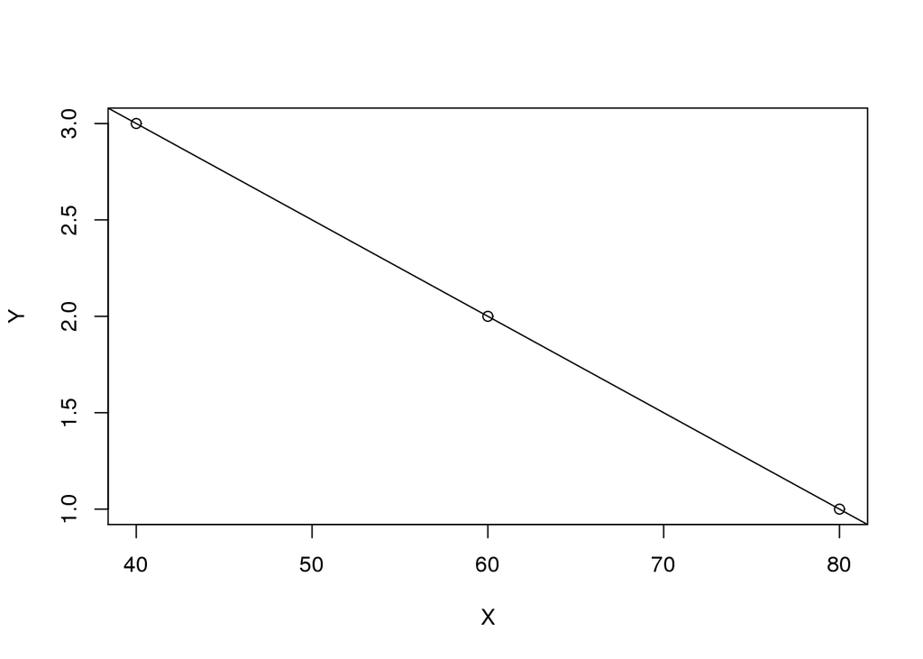

```r
X <- c(40,60,80)
Y <- c(3,2,1)
##lets see this visually
plot(X,Y)
abline(lm(Y~X))
```

```r
###confirm our solution is accurate
lm(Y~X)$coefficients
```

```
## (Intercept)           X
##        5.00       -0.05
```

## Introducing the Idea of Regression

- Regression is a method for estimating the coefficients when there is not an exact solution to the equations.
- Regression seeks to minimize the distance between the observations and a theoretical line.
- By minimizing the distances we can arrive at better estimates of our coefficients and provide better predictions!

```r
#insert tom code here
library(ggplot2)
d <- mtcars
fit <- lm(mpg ~ hp, data = d)

d$predicted <- predict(fit)   # Save the predicted values
d$residuals <- residuals(fit) # Save the residual values

# Quick look at the actual, predicted, and residual values
library(dplyr)
d %>% select(mpg, predicted, residuals)
```

```
##                      mpg predicted   residuals
## Mazda RX4           21.0 22.593750 -1.59374995
## Mazda RX4 Wag       21.0 22.593750 -1.59374995
## Datsun 710          22.8 23.753631 -0.95363068
## Hornet 4 Drive      21.4 22.593750 -1.19374995
## Hornet Sportabout   18.7 18.158912  0.54108812
## Valiant             18.1 22.934891 -4.83489134
## Duster 360          14.3 13.382932  0.91706759
## Merc 240D           24.4 25.868707 -1.46870730
## Merc 230            22.8 23.617174 -0.81717412
## Merc 280            19.2 21.706782 -2.50678234
## Merc 280C           17.8 21.706782 -3.90678234
## Merc 450SE          16.4 17.817770 -1.41777049
## Merc 450SL          17.3 17.817770 -0.51777049
## Merc 450SLC         15.2 17.817770 -2.61777049
## Cadillac Fleetwood  10.4 16.112064 -5.71206353
## Lincoln Continental 10.4 15.429781 -5.02978075
## Chrysler Imperial   14.7 14.406357  0.29364342
## Fiat 128            32.4 25.595794  6.80420581
## Honda Civic         30.4 26.550990  3.84900992
## Toyota Corolla      33.9 25.664022  8.23597754
## Toyota Corona       21.5 23.480718 -1.98071757
## Dodge Challenger    15.5 19.864619 -4.36461883
## AMC Javelin         15.2 19.864619 -4.66461883
## Camaro Z28          13.3 13.382932 -0.08293241
## Pontiac Firebird    19.2 18.158912  1.04108812
## Fiat X1-9           27.3 25.595794  1.70420581
## Porsche 914-2       26.0 23.890087  2.10991276
## Lotus Europa        30.4 22.389065  8.01093488
## Ford Pantera L      15.8 12.086595  3.71340487
## Ferrari Dino        19.7 18.158912  1.54108812
## Maserati Bora       15.0  7.242387  7.75761261
## Volvo 142E          21.4 22.661978 -1.26197823
```

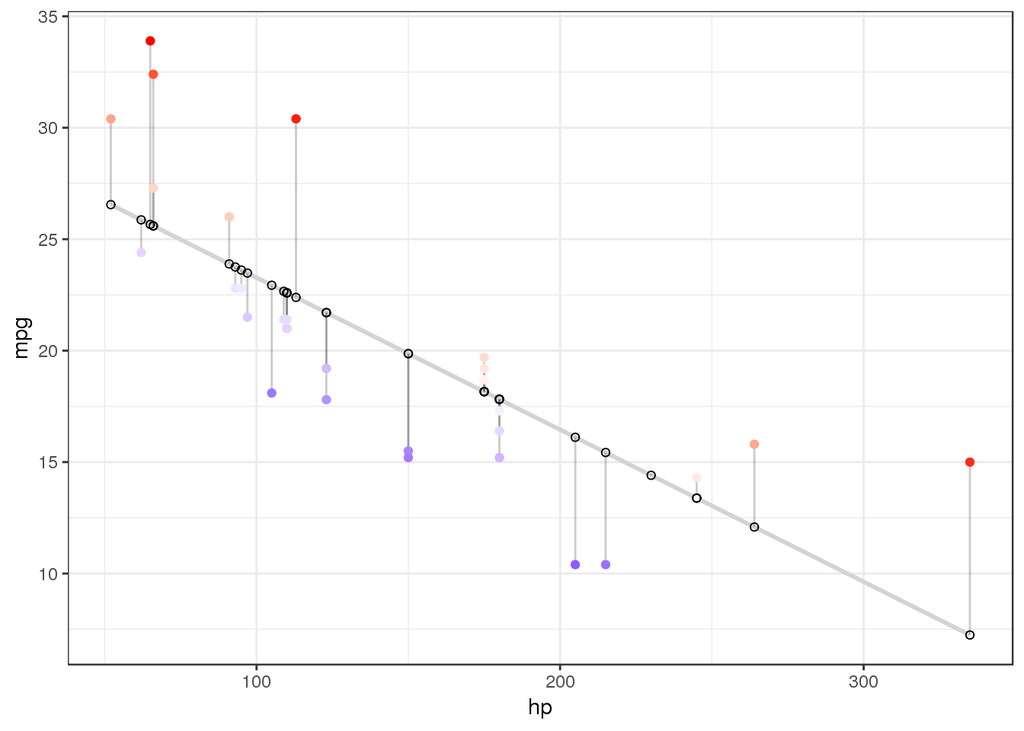

```r
ggplot(d, aes(x = hp, y = mpg)) +
  geom_smooth(method = "lm", se = FALSE, color = "lightgrey") +
  geom_segment(aes(xend = hp, yend = predicted), alpha = .2) +

  # > Color adjustments made here...
  geom_point(aes(color = residuals)) +  # Color mapped here
  scale_color_gradient2(low = "blue", mid = "white", high = "red") +  # Colors to use here
  guides(color = FALSE) +
  # <

  geom_point(aes(y = predicted), shape = 1) +
  theme_bw()
```

## Mathematics of Regression

- The next two points in this lecture we will go over the mathematics of regression and arrive at different solutions to the same problem.
- The idea is to hopefully shed light on the intuition behind these models and provide you with the tools to expand even further on them.

# Matrix Form

- With three points solving a linear system using substitution is easy, but what about 1000 points?
- We can rewrite the equations in matrix form as: $Ax = b$ which becomes:
  $$\underbrace{\left[\begin{array}{cc}
  1 & 40\\
  1 & 60\\
  1 & 80
  \end{array}\right]}_A
  \underbrace{\left[\begin{array}{cc}
  C\\
  \beta
  \end{array}\right]}_X=\underbrace{\left[\begin{array}{cc}
  3\\
  2\\
  1
  \end{array}\right]}_b$$
- Why is this useful?  
  - We can use linear algebra to solve the system of equations with a computer!
- We need to solve for $x$…  
  - Take the inverse of $A$ and $x$ becomes $\frac{1}{A} * b$

```r
library(MASS)

X <- c(40,60,80)
Y <- c(3,2,1)

A <- cbind(rep(1,length(X)),as.numeric(X))
B <- as.matrix(Y)

###we can use the ginv function from MASS to take the inverse
ginv(A)%*%B
```

```
##       [,1]
## [1,]  5.00
## [2,] -0.05
```

# Introducing Least Squares Estimation

### How Do We Estimate the Coefficients When there is no Solution to the Linear System?

- If there isn’t a solution, we attempt to seek the $x$ that gets closest to being a solution  
  - In least squares we minimize the sum of squared residuals where  
  - Residuals are the distance between the points on a fitted line vs the observed points  
  - Thus we minimize the distances between observed and theoretical points, hence $r = b - Ax$  
  - What is the length of $r$?  
  - We find the inner product which is $r * r$ or $r^2$  
  - In matrix algebra it is particularly easy to find the length of a squared residual, $r^{T}r$  
  - This ‘easiness’ is why least squares is used for virtually everything!
- Since $r = b- Ax$, with replacement we get $(b-Ax)^{T}(b-Ax)$  
  - Here we need to solve for $x$, which we will not do here!
- Once we solve for $x$ we get $x =(A^{T}A)^{-1} A^{T}b$
- Assumptions  
  1 Since residuals are squared, the assumption follows that residuals are normally distributed  
  - Otherwise you will have influential points who weight the slope of the line!  
  2 More rows than columns  
  3 Linear relationship  
  4 Homoscedasticity of residuals or equal variance  
  - No pattern in the residuals  
  5 No auto-correlation of residuals  
  6 No multivariate multicollinearity (not needed for this example)

### Now Let’s Use Our New Equation!

The R function solve is used to find the inverse…

```r
X <- c(40,60,80)
Y <- c(3,2,1)

A <- cbind(rep(1,length(X)),as.numeric(X))
B <- as.matrix(Y)

###use solve, t() for transpose and %*% for matrix multiplication
solve(t(A)%*%A) %*% t(A) %*% B
```

```
##       [,1]
## [1,]  5.00
## [2,] -0.05
```

```r
#as we expect, same solution
lm(Y~X)$coefficients
```

```
## (Intercept)           X
##        5.00       -0.05
```

### Let’s Try This on a Larger Model

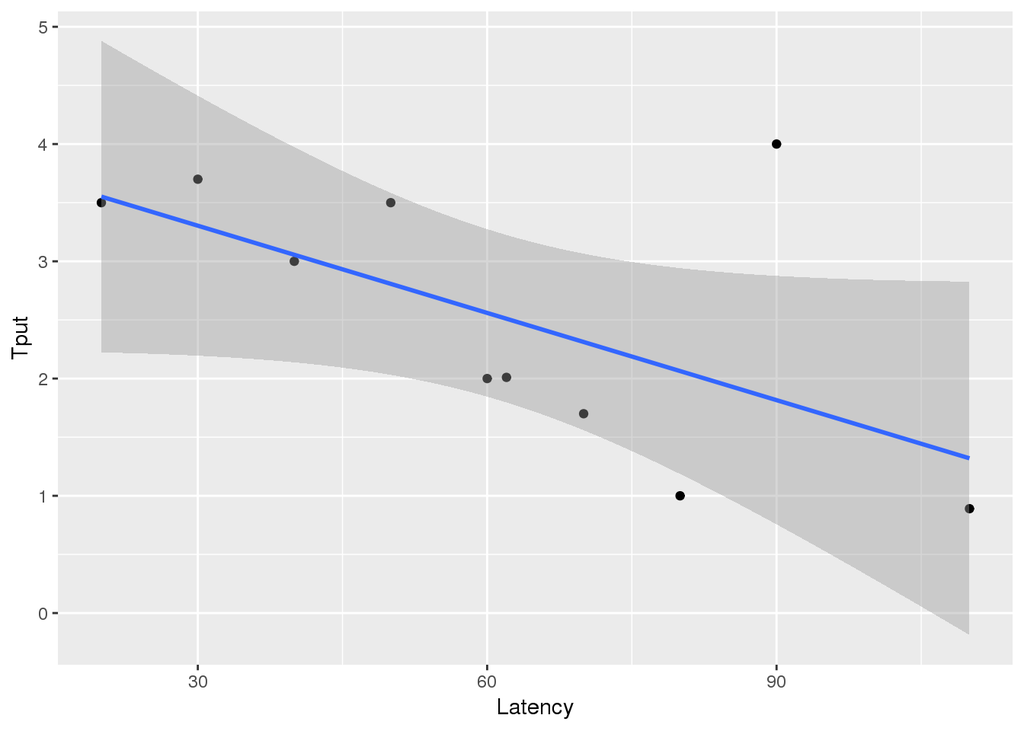

```r
df <- read.csv("matrixexample.csv", stringsAsFactors=FALSE)
library(ggplot2)

ggplot(df) +
    geom_point(aes(x=Latency,y=Tput))+
    geom_smooth(aes(x=Latency,y=Tput),method='lm',formula=y~x)
```

```r
###lets look at the base R function to see what we should expect...
lmmod <- lm(Tput~Latency,data=df)

coeftable <- data.frame(Model='Base LM',Intercept = lmmod$coefficients[1],Slope = lmmod$coefficients[2])

###define X & Y as their respective matrices
A <- cbind(rep(1,nrow(df)),as.numeric(df$Latency))
B <- as.matrix(df$Tput)

###use forward solve to find the coefficients using our definition!
coefs <- solve(t(A)%*%A, t(A)%*%B)

coeftable <- rbind(coeftable,
                                     data.frame(Model='LA LM',Intercept = coefs[1],Slope = coefs[2]))

coefs
```

```
##            [,1]
## [1,]  4.0475639
## [2,] -0.0247968
```

## Calculus Solution

- We have the equation of a line as: -$Y = mx + b$
- It is commonly accepted that we can find a best fit line (least squares) with the following equations:

$$b = \overline{Y} - m*\overline{X}$$
$$m = \displaystyle \frac{\sum_{x = 1}^{x=n} (Y_{i}-\overline{Y})*(X_i-\overline{X})}{\sum_{x = 1}^{x=n}(X_i - \overline{X})^2}$$

- Do we have any idea where these come from though? Using calculus, we can understand how we get to these.
- Lets look at how we do this we will name the sum of squares Q.

$$Q = \sum_{i = 1}^{n} (Y_i-\hat{Y})^2 = \sum_{i = 1}^{n} (Y_i-b - mX_i)^2$$

- Q will be minimized where the derivative wrt b is 0 and where derivative wrt m is 0 first we look wrt b

$$\frac{\delta Q}{\delta b} = \sum_{i = 1}^{n} -2(Y_i-b - mX_i)$$
$$\frac{\delta Q}{\delta b} = \sum_{i = 1}^{n}Y_i-\sum_{i = 1}^{n}b - \sum_{i = 1}^{n}mX_i$$
$$\sum_{i = 1}^{n}b= \sum_{i = 1}^{n}Y_i - \sum_{i = 1}^{n}mX_i$$
$$n*b= \sum_{i = 1}^{n}Y_i - \sum_{i = 1}^{n}mX_i$$
$$b= \frac{\sum_{i = 1}^{n}Y_i}{n} - \frac{\sum_{i = 1}^{n}mX_i}{n}$$
$$b= \overline{Y}-m*\overline{X}$$

- Derivative wrt m
  $$\frac{\delta Q}{\delta m} = \sum_{i = 1}^{n} -2(Y_i-b - mX_i)*(X_i)$$

$$0 = \sum_{i = 1}^{n}(Y_i-\overline{Y}+m*\overline{X} - mX_i)*(X_i)$$
$$0 = \sum_{i = 1}^{n}Y_i(X_i)-\sum_{i = 1}^{n}\overline{Y}(X_i)+\sum_{i = 1}^{n}m\overline{X}(X_i) - \sum_{i = 1}^{n}mX_i(X_i)$$

$$0 = \sum_{i = 1}^{n}(Y_i-Y)(X_i)-m*\sum_{i = 1}^{n}(X_i - \overline{X})(X_i)$$

### Lets show that:

$$\sum_{i = 1}^{n}(Y_i-Y)(X_i) = \sum_{i = 1}^{n}(Y_i-\overline{Y})(X_i-\overline{X})$$

### So

$$\sum_{i = 1}^{n}(Y_i-\overline{Y})(X_i-\overline{X}) = \sum(Y_iX_i)-\sum(Y_i\overline{X}) - \sum(\overline{Y}X_i)+\sum(\overline{X}\overline{Y})$$

### These two are equivalent

$$\sum(Y_i\overline{X})=\sum(\overline{X}\overline{Y})$$

### The summation of the average from 1 to n is equivalent to the sum of y is

$$0 = \sum_{i = 1}^{n}(Y_i-\overline{Y})(X_i-\overline{X}) =m\sum_{i = 1}^{n}(X_i-\overline{X})(X_i-\overline{X})$$

## Estimating the Standard Errors, T Stats, & P-Values

- How good are our coefficient estimates?
- To measure the estimates we use something called standard errors, t stats and p values.
- The standard error is an estimate of the standard deviation of the coefficients.
- The formula for estimating the standard errors is $\sigma^2 (X^{T}X)^{-1}$
- $\sigma^2$ can be solved to $\frac{\sum (b - A * x)^2}{DF}$  
  - This is equivalent to the sum of squares over the degrees of freedom!  
  - nrows - covariates = degrees of freedom

```r
#degrees of freedom
degrees.freedom <- nrow(A)-ncol(A)
# estimate of sigma-squared, which is the same as the sum of squared residuals over degrees of freedom
dSigmaSq <- sum((B - A%*%coefs)^2)/degrees.freedom
# variance covariance matrix
mVarCovar <- dSigmaSq*solve((t(A)%*%A))
mVarCovar
```

```
##              [,1]          [,2]
## [1,]  0.616838607 -0.0085131072
## [2,] -0.008513107  0.0001391031
```

- We are not done yet!
- This simply gives us a variance-co-variance matrix, we still have to solve for $\sigma^2$ which is the diagonal of the matrix.
- We also need to calculate the p value of the coefficients!
- P values evaluate how well the coefficients are significant and are usable for inference!  
  - High p values mean that the coefficient is not significant.

```r
# coeff. est. standard errors
vStdErr <- sqrt(diag(mVarCovar))
stats <- data.frame(coefs,vStdErr)
names(stats) <- c('Coeff','Std.Err.')
# t stat coefficients over standard errors
stats$TStat <- stats$Coeff/stats$Std.Err.
# calculate the p valuesusing the student t distribution, t stats and degrees of freedom
stats$PVal <- 2*pt(-abs(stats$TStat),degrees.freedom)

stats
```

```
##        Coeff  Std.Err.     TStat         PVal
## 1  4.0475639 0.7853907  5.153567 0.0008705029
## 2 -0.0247968 0.0117942 -2.102457 0.0686744941
```

## Residual Standard Error, R-Squared, and F Statistic

#### Residual Standard Error (Residual Standard Deviation)

Residual standard error is goodness of fit measurement that measures the standard deviation of the residuals. First let us calculate the Residual Standard Error which is simply: $\sqrt{\frac{SSE}{DF}}$ Where SSE is the sum of squares and DF is the degrees of freedom.

```r
pred <- stats[1,1] + stats[2,1]* df$Latency
SSE <- sum((pred-df$Tput)^2)
RSE <- sqrt(SSE/degrees.freedom)
RSE.line <- paste0('Residual standard error: ',RSE,' on ',degrees.freedom,' degrees of freedom')
RSE
```

```
## [1] 0.9789609
```

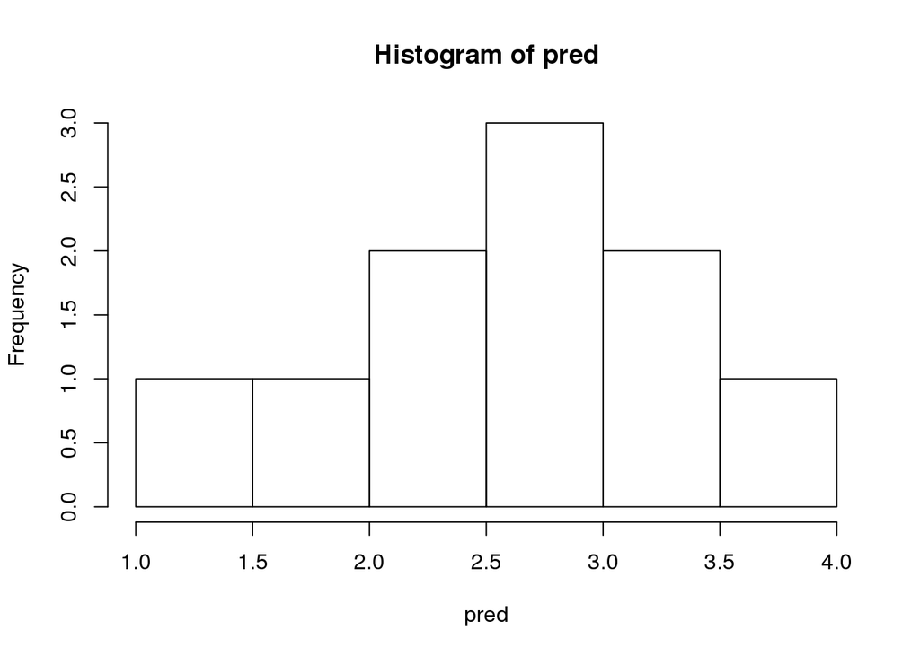

```r
hist(pred)
```

## Coefficient of Determination (R - Squared)

- $R^2$ is defined as $1 - \frac{SSE}{SS_{Total}}$ where $SS_{Total}$ is the sum of squares proportionate to the variance of the data defined by: $SS_{Total} = \sum_{i} (y_i - \bar{y})^2$
- $R^2$ gives a sense of the ‘goodness of fit’ of the model
- In our case it explains how much of the variance is explained by the co-variate, Latency
- $R^2$ does NOT indicate - if the correct model was used - The most appropriate set of variables was used - The co-variates cause changes in the response - The model’s performance
- In our example we can say that 36% of the variance in throughput is explained by latency

```r
R_2 <- 1-SSE/sum((df$Tput-mean(df$Tput))^2)
R_2
```

```
## [1] 0.3558946
```

### Adjusted R - Squared

Adjusted $R^2$ takes into consideration the amount of data in the analysis and the number of co-variates, which both can lead to higher $R^2$ values.

```r
covariates <- nrow(stats)-1

adj_r_2 <- 1 - (((1-R_2)*(nrow(df)-1))/(nrow(df)-covariates-1))

R_2.line <- paste0('Multiple R-squared: ',R_2,', Adjusted R-squared: ',adj_r_2)
adj_r_2
```

```
## [1] 0.2753814
```

## F Test

- The F test is designed to indicate whether or not the model fits the data better than a model with no co-variates.
- In our model the F statistic is not significant which indicates the co-variate, latency does not fit the data well.

```r
#sum of squares for model
SSM <- sum((pred-mean(df$Tput))^2)

#degrees of freedom of the model = number of paramaters (response + covariates) -1
DFM <- 2 - 1

Fstat <- (SSM/DFM)/(SSE/degrees.freedom)

#calculate the p value of the Fstat which uses the probability density funciton of the F distribution on 1 and 8 degrees of freedom
F.pval <- 1-pf(Fstat,1,8)

F.line <- paste0('F-statistic: ',Fstat,' on ',DFM,' and ',degrees.freedom,'DF, p-value: ',F.pval)

Fstat
```

```
## [1] 4.420327
```

```r
F.pval
```

```
## [1] 0.06867449
```

## Comparing our Estimates

```r
model <- list(stats,RSE.line,R_2.line,F.line)

model
```

```
## [[1]]
##        Coeff  Std.Err.     TStat         PVal
## 1  4.0475639 0.7853907  5.153567 0.0008705029
## 2 -0.0247968 0.0117942 -2.102457 0.0686744941
##
## [[2]]
## [1] "Residual standard error: 0.978960897663777 on 8 degrees of freedom"
##
## [[3]]
## [1] "Multiple R-squared: 0.355894590258305, Adjusted R-squared: 0.275381414040593"
##
## [[4]]
## [1] "F-statistic: 4.42032729271474 on 1 and 8DF, p-value: 0.0686744940907074"
```

```r
summary(lmmod)
```

```
##
## Call:
## lm(formula = Tput ~ Latency, data = df)
##
## Residuals:
##     Min      1Q  Median      3Q     Max
## -1.0638 -0.5449 -0.2428  0.2843  2.1841
##
## Coefficients:
##             Estimate Std. Error t value Pr(>|t|)
## (Intercept)  4.04756    0.78539   5.154 0.000871 ***
## Latency     -0.02480    0.01179  -2.102 0.068674 .
## ---
## Signif. codes:  0 '***' 0.001 '**' 0.01 '*' 0.05 '.' 0.1 ' ' 1
##
## Residual standard error: 0.979 on 8 degrees of freedom
## Multiple R-squared:  0.3559, Adjusted R-squared:  0.2754
## F-statistic:  4.42 on 1 and 8 DF,  p-value: 0.06867
```

# QR Decomposition

QR Factorization records the orthogonalization of a matrix, namely, the construction of an orthogonal set that spans the space of column vectors of A. Doing calculations with orthogonal matrices is preferable because (1) they are easy to invert by definition, and (2) they do not magnify errors.

This is simply another method to solve for the coefficients by least squares. It is more stable than the solve solution shared previously, but to my understanding is not as stable as Singular Value Decomposition which can be achieved via the ginv() function in MASS.

```r
#lets try QR decomposition instead

#qr decomposition of matrix A
QR <- qr(A)
Q <- qr.Q(QR)
R <- qr.R(QR)
QR.coefs <- backsolve(R,crossprod(Q,B))

#QR.coefs2 <- forwardsolve(R,crossprod(Q,B))
coeftable <- rbind(coeftable,
                                     data.frame(Model='QR Decomp LM',Intercept = QR.coefs[1],Slope = QR.coefs[2]))
QR.coefs
```

```
##            [,1]
## [1,]  4.0475639
## [2,] -0.0247968
```

# Quantile Regression (L1 Norm)

- What if we didn’t square the residuals and just took the absolute value?
- In fact this is what Gauss wanted to do in the 1800s but he couldn’t easily due to the lack of computer hardware and complexity of the analysis of variance!
- 200 years later we are still using least squares because of the ‘easiness’ of the solution, even though we have the hardware!
- Would Gauss be happy?
- Benefits of LAD - Not sensitive to outliers (because they are not squared!)
- Problems of LAD - Computationally difficult - No current solution to ANOVA - Lack of inference solutions

### Looking at our Throughput Example With Quantreg and our Custom Function

```r
library(quantreg)

quantreg.coefs <- rq(df$Tput~df$Latency)

coeftable <- rbind(coeftable,
                                     data.frame(Model='Quantile LM',Intercept = quantreg.coefs$coefficients[1],Slope = quantreg.coefs$coefficients[2]))

quantreg.coefs$coefficients
```

```
## (Intercept)  df$Latency
##       4.080      -0.029
```

# Gradient Descent

- Gradient descent is an optimization technique for estimating coefficients in a variety of models.
- A cost function is defined which the algorithm seeks to minimize.
- In the case below we define 2 cost functions, L1, and L2 norms.
- Gradient descent works by starting with an estimate of the coefficients, records the error, and moves the coefficients towards the optimized values via the gradient (1st partial derivative) of the cost function.

### Visualizing the Gradient

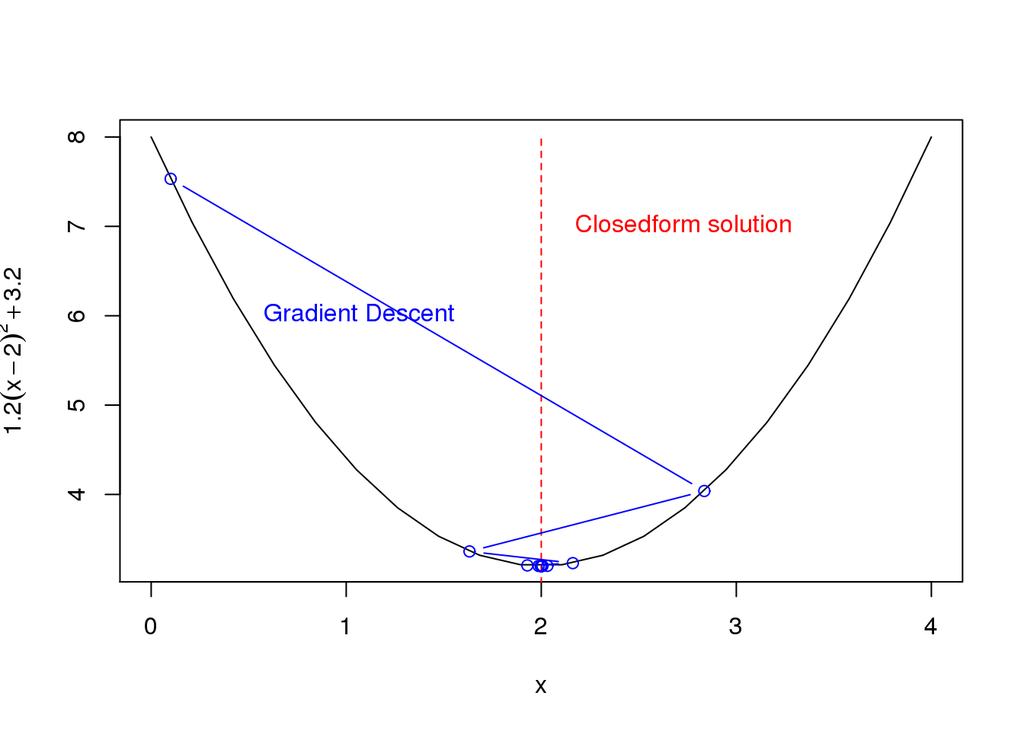

```r
xs <- seq(0,4,len=20) # create some values

# define the function we want to optimize

f <-  function(x) {
1.2 * (x-2)^2 + 3.2
}

# plot the function
plot(xs , f (xs), type="l",xlab="x",ylab=expression(1.2(x-2)^2 +3.2))

# calculate the gradeint df/dx

grad <- function(x){
  1.2*2*(x-2)
}


# df/dx = 2.4(x-2), if x = 2 then 2.4(2-2) = 0
# The actual solution we will approximate with gradeint descent
# is  x = 2 as depicted in the plot below

lines (c (2,2), c (3,8), col="red",lty=2)
text (2.1,7, "Closedform solution",col="red",pos=4)


# gradient descent implementation
x <- 0.1 # initialize the first guess for x-value
xtrace <- x # store x -values for graphing purposes (initial)
ftrace <- f(x) # store y-values (function evaluated at x) for graphing purposes (initial)
stepFactor <- 0.6 # learning rate 'alpha'
for (step in 1:100) {
x <- x - stepFactor*grad(x) # gradient descent update
xtrace <- c(xtrace,x) # update for graph
ftrace <- c(ftrace,f(x)) # update for graph
}

lines ( xtrace , ftrace , type="b",col="blue")
text (0.5,6, "Gradient Descent",col="blue",pos= 4)
```

### Implementation

```r
#define cost functions and their associated gradients
l1.cost <- function(y,yhat,n){
    abs(sum((y - yhat) ))/n
}

l1.gradient <- function(y,yhat){
    (yhat-y)/abs(yhat-y)
}

l2.cost <- function(y,yhat,n){
    sum(1/2*(y - yhat) ^ 2) / n
}

l2.gradient <- function(y,yhat){
yhat - y
}

#define the gradient descent algorithm
gradientDesc <- function(x, y, learn_rate, conv_threshold, max_iter,cost_function) {

 if(identical(cost_function,l1.cost)){
        gradient_fun <- l1.gradient
    }else{
        gradient_fun <- l2.gradient
    }
    #initialize coefficients to zero
    m <- 0
  c <- 0
  n <- nrow(x)
  yhat <- m * x + c
  cost <- cost_function(y,yhat,n)
  converged <- F
  i <- 1
    gradient.info <<- data.frame()

  while(converged == F) {
    ## Implement the gradient descent algorithm
    gradient_m <- (sum((gradient_fun(y,yhat)) * x))
    gradient_c <- (sum(gradient_fun(y,yhat)))
    m_new <- m - learn_rate * ((1 / n) * gradient_m)
    c_new <- c - learn_rate * ((1 / n) * gradient_c)
    m <- m_new
    c <- c_new
    yhat <- m * x + c
    cost_new <- cost_function(y,yhat,n)
    if(cost - cost_new <= conv_threshold) {

      converged = T
      return(paste("Optimal intercept:", c, "Optimal slope:", m))
    }

    if(i %% 10000 == 0){
    gradient.info <<- rbind(gradient.info,data.frame(cost_new,m,c))
    }

    i = i + 1

    if(i > max_iter) {

      converged = T
      return(paste("Optimal intercept:", c, "Optimal slope:", m))
    }
  }
    names(gradient.info) <<- c('Cost','Slope','Intercept')

}


# Run the function
x <- as.matrix(A[,2])
y <- B

#l1 norm
gradientDesc(x, y, 0.0001, 0.01,  2500000,cost_function=l1.cost)
```

```
## [1] "Optimal intercept: 4.10962000000116 Optimal slope: -0.0298000000021362"
```

```r
grad.l1 <- gradient.info[nrow(gradient.info),2:3]

coeftable <- rbind(coeftable,
                                     data.frame(Model='GradientDesc L1',Intercept = grad.l1[,2],Slope = grad.l1[,1]))

#l2 norm
gradientDesc(x, y, 0.0001, 0.01,  2500000,cost_function=l2.cost)
```

```
## [1] "Optimal intercept: 4.04756386434671 Optimal slope: -0.0247967951691364"
```

```r
grad.l2 <- gradient.info[nrow(gradient.info),2:3]

coeftable <- rbind(coeftable,
                                     data.frame(Model='GradientDesc L2',Intercept = grad.l2[,2],Slope = grad.l2[,1]))
```

# Comparing Coefficients Across all Solutions

```r
row.names(coeftable) <- NULL
coeftable
```

```
##             Model Intercept      Slope
## 1         Base LM  4.047564 -0.0247968
## 2           LA LM  4.047564 -0.0247968
## 3    QR Decomp LM  4.047564 -0.0247968
## 4     Quantile LM  4.080000 -0.0290000
## 5 GradientDesc L1  4.109620 -0.0298000
## 6 GradientDesc L2  4.047564 -0.0247968
```

# Comparing MSE

```r
df$L2.Pred <- coeftable[1,2] + coeftable[1,3]*df$Latency
df$L1.Pred <- coeftable[4,2] + coeftable[4,3]*df$Latency
df$Grad.L1.Pred <- coeftable[5,2] + coeftable[5,3]*df$Latency
df$Grad.L2.Pred <- coeftable[6,2] + coeftable[6,3]*df$Latency

L2.MSE <- mean((df$Tput-df$L2.Pred)^2)
L1.MSE <- mean((df$Tput-df$L1.Pred)^2)
L1.Grad.MSE <- mean((df$Tput-df$Grad.L1.Pred)^2)
L2.Grad.MSE <- mean((df$Tput-df$Grad.L2.Pred)^2)

L2.MSE
```

```
## [1] 0.7666916
```

```r
L1.MSE
```

```
## [1] 0.8293984
```

```r
L1.Grad.MSE
```

```
## [1] 0.843542
```

## Visualization of Least Squares, LAD, and Gradient Descent - L1

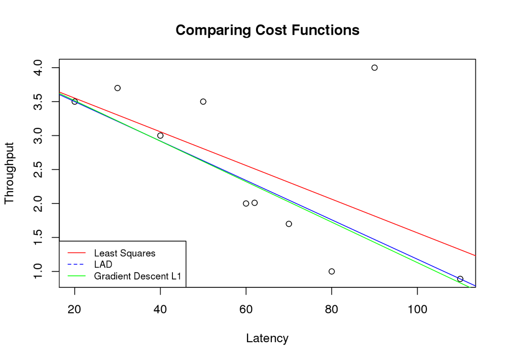

```r
plot(x=df$Latency,y=df$Tput,type='p',
         xlab='Latency',ylab='Throughput',main='Comparing Cost Functions')
abline(a=coeftable[1,2],b=coeftable[1,3],col='red')
abline(a=coeftable[4,2],b=coeftable[4,3],col='blue')
abline(a=coeftable[5,2],b=coeftable[5,3],col='green')

legend('bottomleft', legend=c("Least Squares", "LAD", 'Gradient Descent L1'),
       col=c("red", "blue","green"), lty=1:2, cex=0.8)
```

# Autoregression

Auto-regression is an extension of least squares estimation and is used for time series analysis. Auto-regressive models fit the form:
$$y_t = \mu + \phi y_{t-1}$$

### Let’s Analyze Hyndman’s Birth Data

```r
births <- scan("http://robjhyndman.com/tsdldata/data/nybirths.dat")

Y.lag <- dplyr::lag(births)
Y.lag <- Y.lag[2:length(Y.lag)]
Y.lag <- cbind(rep(1.0,167),Y.lag)
Y.hat <- births[2:length(births)]

solve(t(Y.lag)%*%Y.lag) %*% t(Y.lag) %*% Y.hat
```

```
##            [,1]
##       5.2537974
## Y.lag 0.7904983
```

### Let’s Compare to ARIMA

```r
birthsts <- ts(births)

armod <-arima(birthsts,order=c(1,0,0),include.mean=T,method="CSS")
#arima's 'intercept' is actually the model's mean, to find the intercept we use the following formula:
armod$coef
```

```
##        ar1  intercept
##  0.7904779 25.0774456
```

ARIMA’s ‘intercept’ is actually the model’s mean, to find the intercept we use the following formula:

$$X = \mu (1-\phi)$$
Or conversely if we have the intercept as in our example:

$$\mu = \frac{X}{(1-t)}$$

Thus our coefficients are:

```r
armod$coef[1]
```

```
##       ar1
## 0.7904779
```

```r
armod$coef[2]*(1-armod$coef[1])
```

```
## intercept
##   5.25428
```

Which checks out…

For more examples of how to set up time series models from scratch see https://people.duke.edu/~rnau/411arim.htm

### What About Autoregression with LAD?

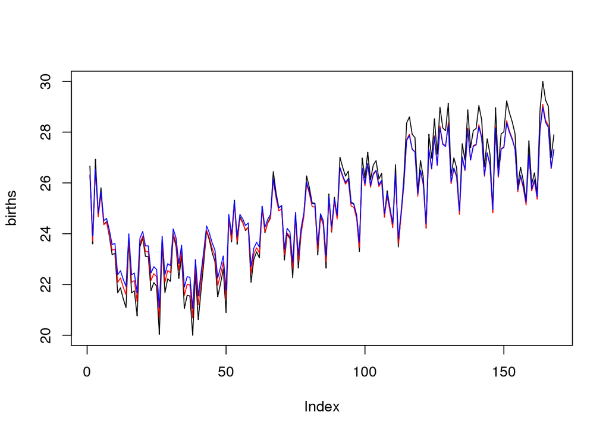

```r
source('rqlp.R',local=T)

births <- scan("http://robjhyndman.com/tsdldata/data/nybirths.dat")

Y.lag <- dplyr::lag(births)
Y.lag <- Y.lag[2:(length(Y.lag))]
Y <- Y.lag
Y.hat <- births[2:(length(births))]

mod.rq.coefs <- rq_LP(Y,Y.hat)


births <- scan("http://robjhyndman.com/tsdldata/data/nybirths.dat")

Y.lag <- dplyr::lag(births)
Y.lag <- Y.lag[2:length(Y.lag)]
Y.lag <- cbind(rep(1.0,167),Y.lag)
Y.hat <- births[2:length(births)]

lsmod <- solve(t(Y.lag)%*%Y.lag) %*% t(Y.lag) %*% Y.hat

lsmod.pred <- function(x){
    lsmod[1]+lsmod[2]*x
}

lsout <- lsmod.pred(births)

mod.predict <- function(x){
mod.rq.coefs[1] + mod.rq.coefs[2]*x
}

rqout <- mod.predict(births)

table.mods <- data.frame('Actual'=births,
                                                 'LAD'=rqout,
                                                 'LS'=lsout,
                                                 'MAPE.LAD'=abs((births-rqout)/births)/length(births)*100,
                                                 'MAPE.LS'=abs((births-lsout)/births)/length(births)*100)

LS.mape <- sum(table.mods$MAPE.LS)
LAD.mape <- sum(table.mods$MAPE.LAD)

table.mods$BetterMod <- ifelse(table.mods$MAPE.LAD>table.mods$MAPE.LS,'LAD','Least Squares')

###red dots are closer to the actuals!!!
plot(births,col='black',type='l')
points(rqout,col='red',type='l')
points(lsout,col='blue',type='l')
```

```r
LS.mape
```

```
## [1] 1.648909
```

```r
LAD.mape
```

```
## [1] 1.259946
```

# Robust Regression

As we can see LAD performs better in some scenarios than OLS, and in this model has a lower MAPE.

This leads us to the question, can we combine the two?

The answer is yes, and this leads us to something called Huber loss which is a current research interest.

Tukey BiWeight?

# Further Reading

### OLS Vs LAD VS Quantile Regression

https://www.unc.edu/courses/2007spring/biol/145/001/docs/lectures/Oct29.html

### Huber Loss

https://web.as.uky.edu/statistics/users/pbreheny/764-F11/notes/12-1.pdf